# 4η Εργασία στην Διερευνητική Ανάλυση και Οπτικοποίηση Δεδομένων

Konstantinos Pasvantis

## Ερώτημα (α) (Καθαρισμός δεδομένων)

Αρχικά φορτώνουμε όλες τις απαραίττητες βιβλιοθήκες που θα χρειαστούμε

```r
library(tidyverse)
```

```r
library(dplyr)
library(ggplot2)
library(stringr)
results<-read.csv('results.csv')
results
```

| Gender | Event | Location | Year | Medal | Name | Nationality | Result |
| --- | --- | --- | --- | --- | --- | --- | --- |
| M | 10000M Men | Rio | 2016 | G | Mohamed FARAH | USA | 25:05.17 |
| M | 10000M Men | Rio | 2016 | S | Paul Kipngetich TANUI | KEN | 27:05.64 |
| M | 10000M Men | Rio | 2016 | B | Tamirat TOLA | ETH | 27:06.26 |
| M | 10000M Men | Beijing | 2008 | G | Kenenisa BEKELE | ETH | 27:01.17 |
| M | 10000M Men | Beijing | 2008 | S | Sileshi SIHINE | ETH | 27:02.77 |
| M | 10000M Men | Beijing | 2008 | B | Micah KOGO | KEN | 27:04.11 |
| M | 10000M Men | Sydney | 2000 | G | Haile GEBRSELASSIE | ETH | 27:18.20 |
| M | 10000M Men | Sydney | 2000 | S | Paul TERGAT | KEN | 27:18.29 |
| M | 10000M Men | Sydney | 2000 | B | Assefa MEZGEBU | ETH | 27:19.75 |
| M | 10000M Men | Barcelona | 1992 | G | Khalid SKAH | MAR | 27:46.70 |

[output cut: 2396 more lines]

Παρατηρώ ότι υπάρχουν λίγες εγγραφές που δεν έχουν αποτελέσματα, ή που τα αποτελέσματα έχουν την τιμή None, οπότε μπορούμε να τις διαγράψουμε και να κρατήσουμε το κανούργιο dataset.

```r
results<-results[results$Name!="" & results$Result!="None",]
results
```

|  | Gender | Event | Location | Year | Medal | Name | Nationality | Result |
| --- | --- | --- | --- | --- | --- | --- | --- | --- |
| 1 | M | 10000M Men | Rio | 2016 | G | Mohamed FARAH | USA | 25:05.17 |
| 2 | M | 10000M Men | Rio | 2016 | S | Paul Kipngetich TANUI | KEN | 27:05.64 |
| 3 | M | 10000M Men | Rio | 2016 | B | Tamirat TOLA | ETH | 27:06.26 |
| 4 | M | 10000M Men | Beijing | 2008 | G | Kenenisa BEKELE | ETH | 27:01.17 |
| 5 | M | 10000M Men | Beijing | 2008 | S | Sileshi SIHINE | ETH | 27:02.77 |
| 6 | M | 10000M Men | Beijing | 2008 | B | Micah KOGO | KEN | 27:04.11 |
| 7 | M | 10000M Men | Sydney | 2000 | G | Haile GEBRSELASSIE | ETH | 27:18.20 |
| 8 | M | 10000M Men | Sydney | 2000 | S | Paul TERGAT | KEN | 27:18.29 |
| 9 | M | 10000M Men | Sydney | 2000 | B | Assefa MEZGEBU | ETH | 27:19.75 |
| 10 | M | 10000M Men | Barcelona | 1992 | G | Khalid SKAH | MAR | 27:46.70 |

[output cut: 2341 more lines]

Τα κυριότερα θέματα που παρατηρώ όσον αφορά την μορφοποίηση των αποτελεσμάτων είναι: 1) Στις περισσότερες εγγραφες οι ώρες ξεχωρίζουν απο τα λεπτά με το ‘:’, αλλά υπάρχουν και μερικές εγγραφές που έχουν το γράμμα h για να δείξουν ότι είναι οι ώρες, οπότε θα πάω και θα αντικαταστήσω το ‘h’ με το ‘:’,  
2) Μερικά αποτελέσματα έχουν τους χαρακτήρες ‘est’ και ‘P.’ οπότε θα πρέπει να τα διαγράψω.

```r
results$Result<- str_replace(results$Result, "h", ":")
results$Result<- str_replace(results$Result, "est", "")
results$Result<- str_replace(results$Result, "P.", "")
```

Για να δουλεψω καλύτερα με τα δεδομένα μου, χωρίζω το dataset σε 4 επιμέρους dataset, που το καθένα έχει διαφορετικά αθλήματα. Πιο συγκεκριμένα θα κάνω dataset με αθλήματα ρίψεων, δρόμου, αλμάτων και για το Δέκαθλο - Έπταθλο.

```r
Race_Events=c('10000M Men','100M Men','110M Hurdles Men','1500M Men','200M Men'
              ,'20Km Race Walk Men','3000M Steeplechase Men','400M Hurdles Men',
              '400M Men','4X100M Relay Men','4X400M Relay Men','5000M Men',
              '50Km Race Walk Men','800M Men','Marathon Men','10000M Women','100M Women','100M Hurdles Women','1500M Women','200M Women'
              ,'20Km Race Walk Women','3000M Steeplechase Women','400M Hurdles Women',
              '400M Women','4X100M Relay Women','4X400M Relay Women','5000M Women',
              '50Km Race Walk Women','800M Women','Marathon Women')


Throwing_Events=c('Discus Throw Men','Hammer Throw Men','Javelin Throw Men',
                  'Shot Put Men','Discus Throw Women','Hammer Throw Women','Javelin Throw Women',
                  'Shot Put Women')

Jump_Events=c('High Jump Men','Long Jump Men','Pole Vault Men','Triple Jump Men',
              'High Jump Women','Long Jump Women','Pole Vault Women','Triple Jump Women')

Decathlon_Events=c('Decathlon Men','Heptathlon Women')

Race<-subset(results,Event %in% Race_Events)
Decathlon<-subset(results,Event %in% Decathlon_Events)
Throwing<-subset(results,Event %in% Throwing_Events)
Jumps<-subset(results,Event %in% Jump_Events)
```

Επίσης παρατηρώ ότι στα αθλήματα, εκτός από την ονομασία των αθλημάτων εμφανίζεται και το φύλο που αγωνίζεται, κάτι το οποίο είναι περιττό εφόσον υπάρχει ήδη η στήλη με τα φύλα.

```r
Race$Event<-str_replace(Race$Event, "Men", "")
Race$Event<-str_replace(Race$Event, "Women", "")
Decathlon$Event<-str_replace(Decathlon$Event, "Men", "")
Decathlon$Event<-str_replace(Decathlon$Event, "Women", "")
Throwing$Event<-str_replace(Throwing$Event, "Men", "")
Throwing$Event<-str_replace(Throwing$Event, "Women", "")
Jumps$Event<-str_replace(Jumps$Event, "Men", "")
Jumps$Event<-str_replace(Jumps$Event, "Women", "")
```

Ακόμα, πρέπει να μετατρέψω τα αποτελέσματα σε σωστό τύπο δεδομένων:

```r
Jumps$Result<-as.numeric(Jumps$Result)
glimpse(Jumps)
```

```
## Rows: 346
## Columns: 8
## $ Gender      <chr> "M", "M", "M", "M", "M", "M", "M", "M", "M", "M", "M", "M"~
## $ Event       <chr> "High Jump ", "High Jump ", "High Jump ", "High Jump ", "H~
## $ Location    <chr> "Rio", "Rio", "Rio", "Beijing", "Beijing", "Beijing", "Syd~
## $ Year        <int> 2016, 2016, 2016, 2008, 2008, 2008, 2000, 2000, 2000, 1992~
## $ Medal       <chr> "G", "S", "B", "G", "S", "B", "G", "S", "B", "G", "S", "B"~
## $ Name        <chr> "Derek DROUIN", "Mutaz Essa BARSHIM", "Bohdan BONDARENKO",~
## $ Nationality <chr> "CAN", "QAT", "UKR", "RUS", "GBR", "RUS", "RUS", "CUB", "A~
## $ Result      <dbl> 2.38, 2.36, 2.33, 2.36, 2.34, 2.34, 2.35, 2.32, 2.32, 2.34~
```

```r
Throwing$Result<-as.numeric(Throwing$Result)
glimpse(Throwing)
```

```
## Rows: 379
## Columns: 8
## $ Gender      <chr> "M", "M", "M", "M", "M", "M", "M", "M", "M", "M", "M", "M"~
## $ Event       <chr> "Discus Throw ", "Discus Throw ", "Discus Throw ", "Discus~
## $ Location    <chr> "Rio", "Rio", "Rio", "Beijing", "Beijing", "Beijing", "Syd~
## $ Year        <int> 2016, 2016, 2016, 2008, 2008, 2008, 2000, 2000, 2000, 1992~
## $ Medal       <chr> "G", "S", "B", "G", "S", "B", "G", "S", "B", "G", "S", "B"~
## $ Name        <chr> "Christoph HARTING", "Piotr MALACHOWSKI", "Daniel JASINSKI~
## $ Nationality <chr> "GER", "POL", "GER", "EST", "POL", "LTU", "LTU", "GER", "R~
## $ Result      <dbl> 68.37, 67.55, 67.05, 68.82, 67.82, 67.79, 69.30, 68.50, 68~
```

```r
Decathlon$Result<-as.numeric(Decathlon$Result)
glimpse(Decathlon)
```

```
## Rows: 103
## Columns: 8
## $ Gender      <chr> "M", "M", "M", "M", "M", "M", "M", "M", "M", "M", "M", "M"~
## $ Event       <chr> "Decathlon ", "Decathlon ", "Decathlon ", "Decathlon ", "D~
## $ Location    <chr> "Rio", "Rio", "Rio", "Beijing", "Beijing", "Beijing", "Syd~
## $ Year        <int> 2016, 2016, 2016, 2008, 2008, 2008, 2000, 2000, 2000, 1992~
## $ Medal       <chr> "G", "S", "B", "G", "S", "B", "G", "S", "B", "G", "S", "B"~
## $ Name        <chr> "Ashton EATON", "Kevin MAYER", "Damian WARNER", "Bryan CLA~
## $ Nationality <chr> "USA", "FRA", "CAN", "USA", "BLR", "CUB", "EST", "CZE", "U~
## $ Result      <dbl> 8893, 8834, 8666, 8791, 8551, 8527, 8641, 8606, 8595, 8611~
```

## Ερώτημα (β) (Κατασκευή plot)

Ξεκινάμε παρουσίαζοντας τις 20 χώρες που έχουν λάβει τα περισσότερα χρυσά μετάλλια(η κατηγορία other μετράει τα μετάλλια που έχουν πάρει οι υπόλοιπες χώρες μαζί).

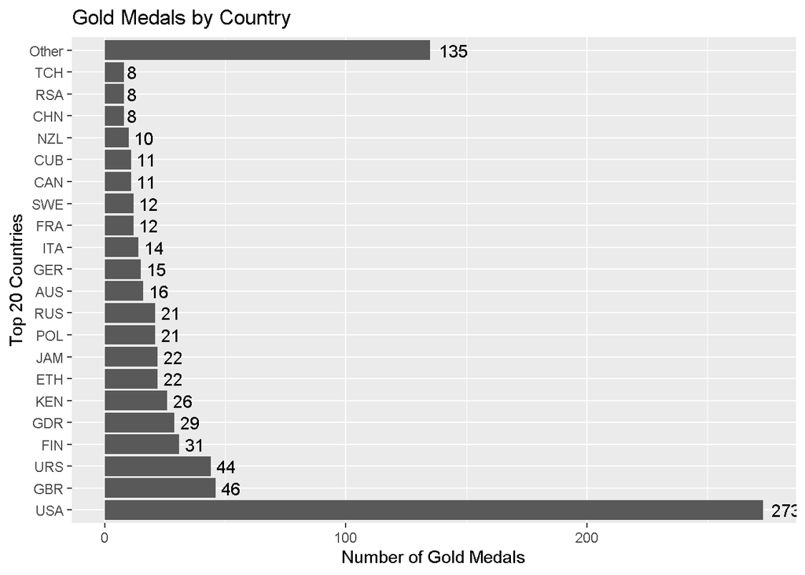

```r
gold_med_bycountry<-results%>%filter(Medal=='G')

ggplot(gold_med_bycountry,aes(x=fct_lump_n(fct_infreq(Nationality),n=20)))+geom_bar()+geom_text(stat='count',aes(label=..count..),hjust=-0.3)+coord_flip()+ggtitle("Gold Medals by Country")+xlab("Top 20 Countries") + ylab("Number of Gold Medals")
```

Στην συνέχεια παρουσιάζουμε violin plots για τα αποτελέσματα των αλμάτων ανα φύλο.

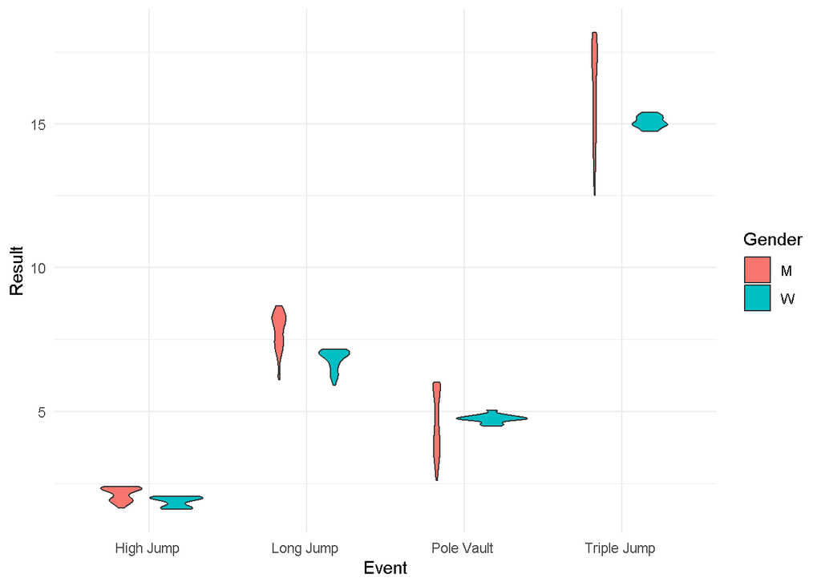

```r
ggplot(Jumps,aes(x=Event,y=Result,fill=Gender))+geom_violin(position = position_dodge(0.7))+theme_minimal()
```

Το επόμενο γράφημα δείχνει το σκορ για κάθε άθλημα ρίψης το οποίο πήρε το χρυσό μετάλλιο ανα χρονιά.

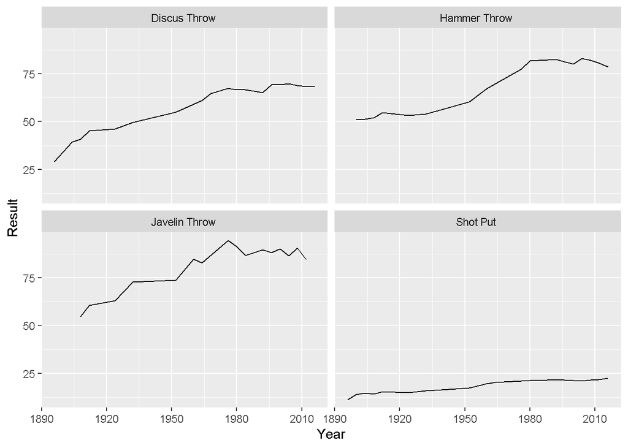

```r
Golds_for_Male_Throwers<-Throwing%>%filter(Medal=='G',Gender=='M')%>%arrange(Event,Year)


ggplot(Golds_for_Male_Throwers,aes(x=Year,y=Result))+geom_line()+facet_wrap(.~Event)
```

Στην συνέχεια βλέπουμε boxplots για τα αποτελέσματα των ρίψεων για κάθε φύλο

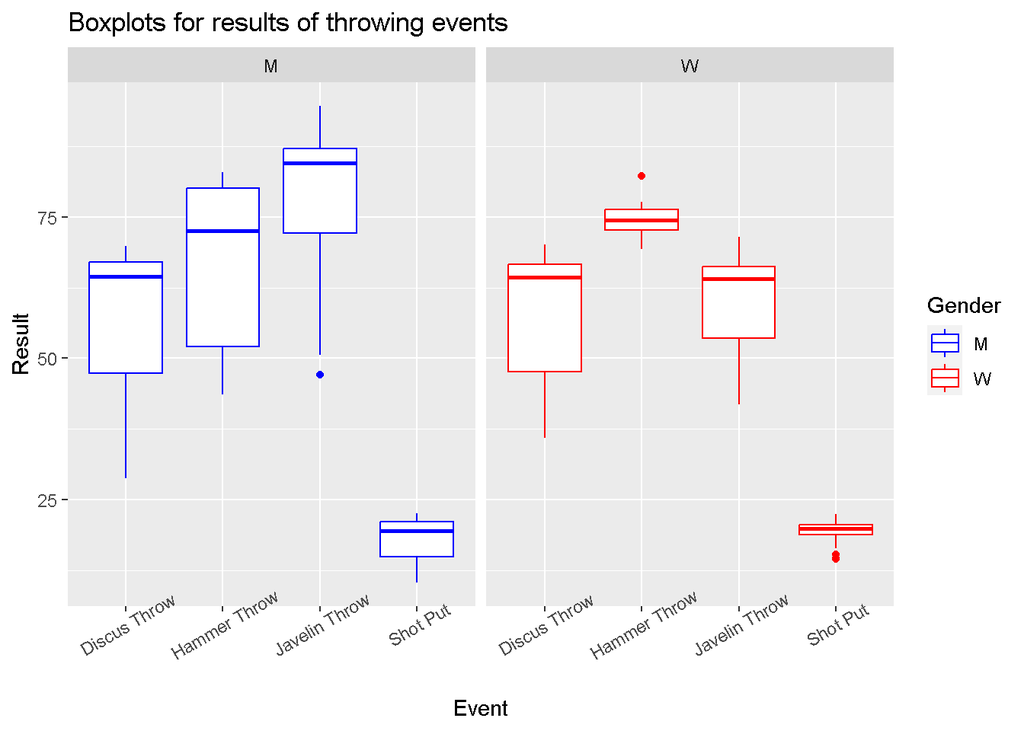

```r
ggplot(Throwing,aes(x=Event,y=Result,color=Gender))+geom_boxplot()+facet_wrap(~Gender)+ggtitle("Boxplots for results of throwing events")+scale_color_manual(values = c('W'='red','M'='blue'))+theme(axis.text.x = element_text(angle = 30))
```

Τέλος, αναφερόμαστε μόνο στο Έπταθλον, δημιουργώντας ένα γράφημα που μας δείχνει ποιό ήταν κάθε χρονιά το σκορ που κέρδισε το χρυσό, το ασημένιο ή το χάλκινο μετάλλιο.

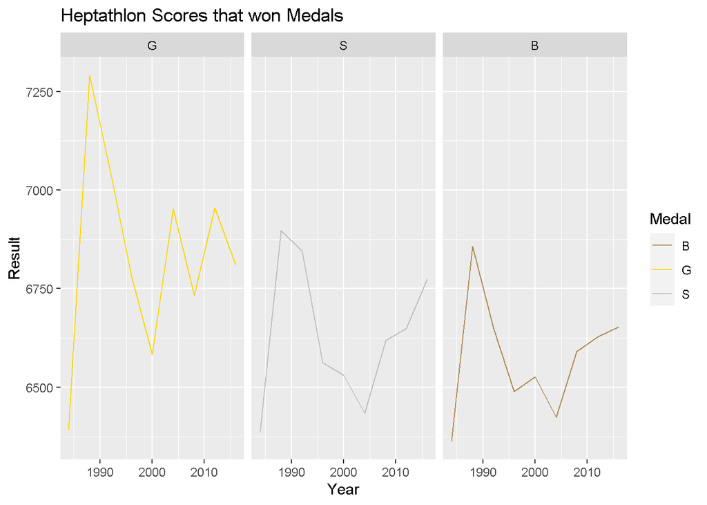

```r
Decathlon%>%filter(Gender=='W')%>%ggplot(aes(x=Year,y=Result,color=Medal))+geom_line()+facet_wrap(~factor(Medal,levels=c('G','S','B')))+
  scale_color_manual(values = c('G'='gold','B'='#b08d57','S'='#c0c0c0'))+ggtitle('Heptathlon Scores that won Medals')
```